# carboxysome_partitioning_and_prob_dists

```
[NbConvertApp] Converting notebook /content/codeexample3_carboxysome_partitioning_and_prob_dists_group_work_from_Abe_1_group_2.ipynb to html
```

Group members: Elizabeth Mahoney, Aryelle Wright, Hannah Miller, Ava Kowalski

Problem 1 -- Matching the "stories" to the probability distributions (10 points)

For this problem, you may want to revisit the Probability Distribution Explorer. For each "story" below, state which probability distribution would best describe the scenario and explain why.

A. The time between large (magnitude 8 or higher) earthquakes.

Exponential distribution because it follows that rare events occur with a rate, beta, per unit time.

B. The number of bases DNA polymerase can replicate before making an error.

Geometric distributions because we perform a series of Bernoulli trials with probability of success, theta, until we get a success. The number of failures, y, before the success is geometrically distributed. We did this in the individual portion of HW9 (problem 2).

C. The number of errors DNA polymerase make when replicating the entire genome.

Binomial distribution because with N Bernoulli trials, each trial has a probility of succes (in this case an error).

D. The chance an instrument in the lab will break a given time we go to use it.

Bernoulli distribution because there are only two possible outcomes, the instrument not breaking or breaking.

E. The number of steps Mines students take in a day. Normal distribution because it follows the definitio of being any quantity that emerges as the sum of a large number of subprocesses.

Grade/comments:

[figure not shown]

Perfect!

10/10

Problem 2 -- The partitioning of carboxysomes (20 points)

Carboxysomes are organelle-like structures that some bacteria have to aid in carbon fixation. Cells generally only have a very few number of carboxysomes (1 to 7), so how they are partitioned to the daughter cells is an interesting question. Researchers specifically looked at cells with 6 carboxysomes, and asked how many went to "daughter cell 1" upon cell division, where the daughter cell of interest was randomly selected. They got the following results:

15% of the time, the daughter cell got 2 carboxysomes 70% of the time, the daughter cell got 3 carboxysomes 15% of the time, the daughter cell got 4 carboxysomes Out of 88 trials, no other number of carboxysomes were ever seen.

A. If the carboxysomes were partitioned randomly, which distribution would best describe the number of carboxysomes seen in daughter cell 1?

B. Simulate this random process of seeing how many carboxysomes go to daughter cell 1. First, simulate with "coin flips" for each of the six carboxysomes in turn, recording how many went to the one cell of interest. Simulate this process 10,000 times, and plot the results. Note that a histogram (with 7 bins) would actually be appropriate here, since there are only a handful of discrete possible results, so there is no concern of binning bias.

```python
#imports

import numpy as np
import matplotlib.pyplot as plt
import random
import seaborn as sns
sns.set()
```

```python
def sim_coinflips(num_reps):
  num_reps_array = np.zeros(num_reps)

  for i in range(num_reps):
    count = 0

    for j in range(6): # repeat for each carboxysome
      carboxy = random.choice(["Y","N"])
      if carboxy == 'Y':
        count += 1
    num_reps_array[i] = count

  return num_reps_array
```

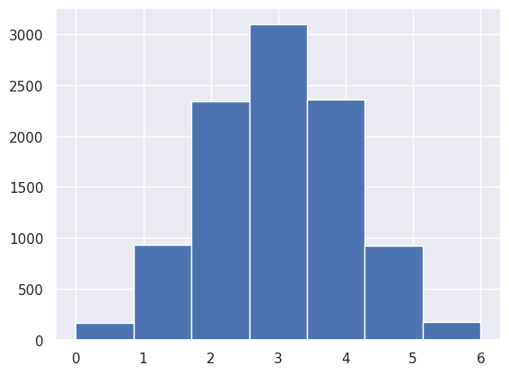

```python
simm = sim_coinflips(10000)
plt.hist(simm, bins = 7);
```

C. Now simulate the process again with a built-function from numpy.random. Again, plot you results as a way to validate your approach in part B.

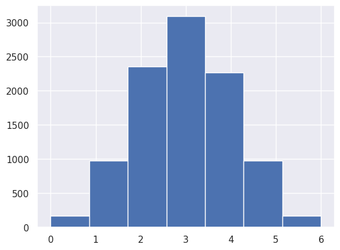

```python
sim = np.random.binomial(6, .5, 10000)
plt.hist(sim, bins = 7);
```

D. Given how the results of your simulations compare to the actual experimental results, do you think the partitioning of carboxysomes is random? Why or why not?

The partitioning of carboxysome is not random, we can see from the binomial distribution that when each carboxysome behaves indipendently with a 50% chance of partition, the experimental results are normally distributed and nonrandom.

grade/comments:

The quantitative pieces look good, but Part A has no answer (-3).

17/20

Problem 3 -- Simulating the Bicoid gradient (20 points)

Bicoid is a key gene in the early development of the fruit fly, Drosophila. The protein is initially only found on the anterior (head) side of the embryo and diffuses further down the embryo over time. This ultimately results in a gradient, with diminishing amounts of Bicoid as you go further along the embryo.

In this problem, we will modify the code for a random walk as shown in class on April 6th to simulate this process of the Bicoid gradient getting set up via a diffusive random walk. For this, we will imagine that all the molecules initially start at position 0, but a key difference will be that molecules cannot take on negative positions. That is, we will treat the left side of the embryo as a boundary that the molecules can not cross. So molecules at position 0 will still have a 50% chance of moving to position 1, but will otherwise stay at position 0.

A. Simulate this modified random walk for 1,000 trajectories (i.e. Bicoid molecules), each with 1,000 steps. Plot the distribution of the final positions of the Bicoid molecules.

```python
n_steps = 1000
n_trajectories = 1000

positions_2D = np.zeros([n_trajectories, n_steps])

for i in range(n_trajectories):

  for j in range(1, n_steps):

    rand = np.random.uniform()

    if rand > 0.5:
      positions_2D[i, j] = positions_2D[i, j-1] + 1

        # step in the negative direction
    else:
      if positions_2D[i, j-1] != 0:
        positions_2D[i, j] = positions_2D[i, j-1] - 1
```

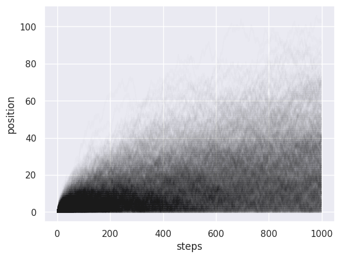

```python
for i in range(n_trajectories):
    plt.plot(positions_2D[i,:], color='k', alpha=0.01)

plt.xlabel('steps')
plt.ylabel('position');
```

Grade/comments:

19/20

Problem 4 -- Variation in binomial partitioning (20 points)

For simplicity, we will assign each molecule an intensity of 1. What we hope to see is that as we increase the total number of fluorescent molecules in the cell, we will get greater variability in the difference between the two daughter cells.

A. Simulate this binomial partitioning for the following number of molecules ( I T O T ): [5,10,25,50,75,100,150]. For each, simulate 1,000 trials of the binomial partitioning for the given number of molecules. Note, you will probably prefer to use numpy's built-in function here to make the code more manageable. Save your results as variables you can call in the coming parts.

```python
fluorsim_5 = np.random.binomial(5, 0.5, 1000)
fluorsim_10 = np.random.binomial(10, 0.5, 1000)
fluorsim_25 = np.random.binomial(25, 0.5, 1000)
fluorsim_50 = np.random.binomial(50, 0.5, 1000)
fluorsim_75 = np.random.binomial(75, 0.5, 1000)
fluorsim_100 = np.random.binomial(100, 0.5, 1000)
fluorsim_150 = np.random.binomial(150, 0.5, 1000)
```

B. With the results of the binomial partitioning, now compute the y-axis values

| I 1 − I 2 | 2 , which serves as a metric of how much the partitioning varies from perfect partitioning. Note that your results from part A will indicate how many molecules went to one of the cells, say daughter cell 1, but you will have to compute how many went to the other daughter cell as well.

```python
I1_5 = np.random.binomial(5, 0.5, 1000)
I2_5 = 5-I1_5

I1_10 = np.random.binomial(10, 0.5, 1000)
I2_10 = 10-I1_10

I1_25 = np.random.binomial(25, 0.5, 1000)
I2_25 = 25-I1_25

I1_50 = np.random.binomial(50, 0.5, 1000)
I2_50 = 50-I1_50

I1_75 = np.random.binomial(75, 0.5, 1000)
I2_75 = 75-I1_75

I1_100 = np.random.binomial(100, 0.5, 1000)
I2_100 = 100-I1_100

I1_150 = np.random.binomial(150, 0.5, 1000)
I2_150 = 150-I1_150
```

```python
y_5 = (np.abs(I1_5-I2_5))/2
y_10 = (np.abs(I1_10-I2_10))/2
y_25 = (np.abs(I1_25-I2_25))/2
y_50 = (np.abs(I1_50-I2_50))/2
y_75 = (np.abs(I1_75-I2_75))/2
y_100 = (np.abs(I1_100-I2_100))/2
y_150 = (np.abs(I1_150-I2_150))/2

y_values = y_5, y_10, y_25, y_50, y_75, y_100, y_150
```

```python
avg_5 = np.mean(y_5)
avg_10 = np.mean(y_10)
avg_25 = np.mean(y_25)
avg_50 = np.mean(y_50)
avg_75 = np.mean(y_75)
avg_100 = np.mean(y_100)
avg_150 = np.mean(y_150)

avg_y_values = [avg_5, avg_10, avg_25, avg_50, avg_75, avg_100, avg_150]
```

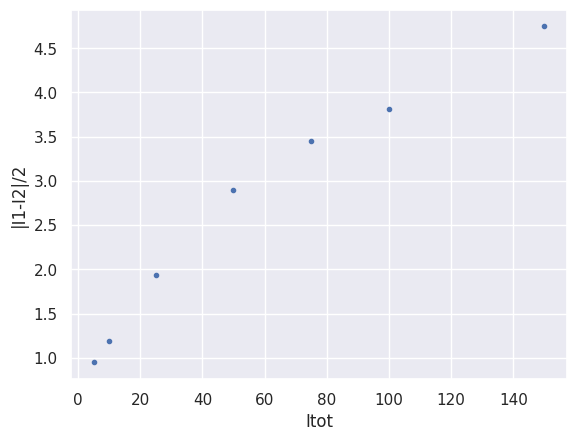

```python
x_values = [5,10,25,50,75,100,150]
plt.plot(x_values, avg_y_values, '.')
plt.xlabel('Itot')
plt.ylabel('|I1-I2|/2');
```

Grade/comments: This looks good overall. You can really trim down your code by running everything withing a for loop. You can define an array such as Itots = [5,10,25,...] and put everything in a loop like for Itot in Itots. Then you can work within arrays to keep from having to do everything individually (-2).

18/20

Overall: 64/70